The format of this lab follows the same format as the previous ones. Your goal is to predict the value of the third column (which will be missing on the test set) using the techniques we have learned so far.

One thing that you are not allowed to use are neural networks. We will see how to use this with images next week.

# Set-up

Read in the following libraries and to load the metadata about the class images:

```r
library(readr)
library(dplyr)
```

```r
library(ggplot2)
library(viridis)
library(stringi)
library(jpeg)
library(glmnet)
library(keras)
f17 <- read_csv("https://statsmaths.github.io/ml_data/f17_photos_2.csv")
```

To get the actual data for the images, you’ll have to download the following files. The first is the smaller images, which you will certainly need for the lab. The second you are free to make use of for negative examples or to extract features from but there is no pressure to do so.

- https://drive.google.com/open?id=0B6_9OUDRaPQsTDFUTXVZb0JnaTg
- https://drive.google.com/open?id=0B6_9OUDRaPQsdzBiX1RmYUZwdDA

Once these are downloaded, you’ll have to run something like this:

```r
x32 <- read_rds("~/Desktop/f17_photos_2_x32.rds")
```

If, for example, the file sits on your Desktop and you have a mac. If you have trouble with any of this, please let me know as soon as possible.

# Lab 17

We start by collapsing the data into a 2-D array and decomposing our data into train and validation sets.

```r
X <- t(apply(x32, 1, cbind))
y <- f17$class

X_train <- X[f17$train_id == "train",]
y_train <- y[f17$train_id == "train"]
```

Next, we start with running the glmnet model as described in class, looking at the coefficients for both min. and 1se. lambda values. We see that for the middle 1024 elements (1023-2048), only 2 of the variables are used.

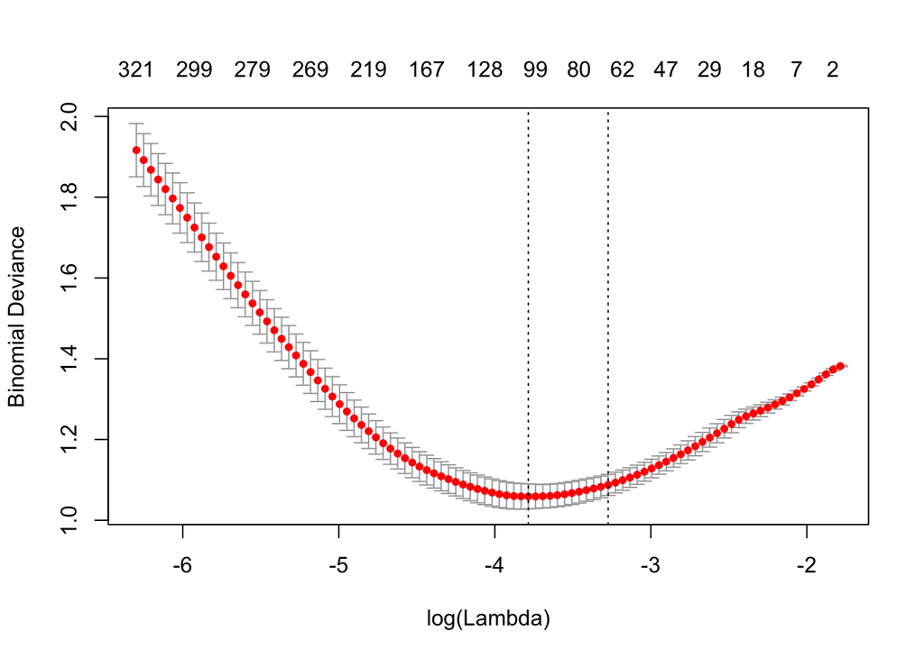

```r
model1 <- cv.glmnet(X_train, y_train, family="binomial", nfolds=5)

beta <- coef(model1, s= c(model1$lambda.1se,model1$lambda.min))

plot(model1)
```

```r
beta[beta[,1] != 0,,drop=FALSE]
```

```
## 67 x 2 sparse Matrix of class "dgCMatrix"
##                         1            2
## (Intercept)  1.7692715361  2.071133277
## V1          -0.0842816117 -0.513800901
## V16         -0.0670302749 -0.136156856
## V48         -0.1534871666 -0.161875989
## V80         -0.0121180368  .
## V81         -0.0479809651 -0.271893389
## V101        -0.0004071277 -0.074593879
## V107        -0.5300018121 -0.642084486
## V161        -0.0352474634 -0.088963697
## V172        -0.2251124724 -0.264870351
## V195        -0.1611814045 -0.166220266
## V231        -0.1626773203 -0.258267221
## V291        -0.4519626164 -0.649293351
## V331        -0.0322581652 -0.122182051
## V359        -0.2860292919 -0.319555701
## V395        -0.1353358942 -0.021656363
## V396        -0.0845642474 -0.204505073
## V425        -0.7133960649 -0.746373244
## V453        -0.1298059145 -0.211927520
## V483        -0.0672171021 -0.145685383
## V493        -0.6070084145 -0.788374213
## V513        -0.0936783509 -0.100488066
## V516        -0.0774247613  .
## V548        -0.2705713201 -0.506725050
## V549        -0.1854820776 -0.262096696
## V578        -0.0778164967 -0.093245957
## V581        -0.1924088179 -0.328861110
## V583        -0.1217513083 -0.165261215
## V675        -0.3604674832 -0.398650565
## V744        -0.1386521449 -0.232471085
## V750        -0.0407906831  .
## V770        -0.6473684636 -0.988844618
## V811        -0.1700481014 -0.175462870
## V842        -0.4355250823 -0.453862484
## V869        -0.1454167550 -0.077457999
## V902        -0.2100901678 -0.319063095
## V903        -0.2646862073 -0.298063011
## V932        -0.1618688723 -0.348187199
```

[output cut: 14 more lines]

```
## V2402        0.1300818832  0.221636715
## V2433        0.0668612275  0.023135071
## V2434        0.0262228262  .
## V2465        0.6411269271  0.778589387
## V2495        0.4117213508  0.433538923
## V2587        0.0624279114  0.471406413
## V2627        0.2816746409  0.558975557
## V2689        0.2176521693  0.205379799
## V2690        0.1460269660  0.184781908
## V2754        0.0371078569  0.044205056
## V2817        0.0666403760  0.095922170
## V2849        0.2457506903  0.263530561
## V3006        0.4830931627  0.707498126
## V3007        0.2068094744  0.219133978
## V3009        0.0198155590  0.156989923
```

Next, let us see how this model performs on our data. We see that using the min. lambda value gives us a slightly higher valid set and a much higher training set.

```r
f17$predict_min <- predict(model1, newx = X, type="class", s = "lambda.min")
predict_1se <- predict(model1, newx = X, type="class", s = "lambda.1se")

tapply(f17$predict_min == y, f17$train_id, mean)
```

```
##      test     train     valid
##        NA 0.8588589 0.7567568
```

```r
tapply(predict_1se == y, f17$train_id, mean)
```

```
##      test     train     valid
##        NA 0.8348348 0.7507508
```

To get a better idea of where our classification fails, let us make a table of the results. We see that the model did a slightly worse job of classifying outside images, and that our dataset has more images inside.

```r
table(y = f17$class, x = f17$predict_min)
```

```
##    x
## y     0   1
##   0 447  76
##   1  99 377
```

Next, I attempt to use the data and build a neural network for classification.

```r
X <- as.matrix(X)

X_train <- X[f17$train_id == "train",]
X_valid <- X[f17$train_id == "valid",]

y_train <- to_categorical(y[f17$train_id == "train"], num_classes=2)
y_valid <- to_categorical(y[f17$train_id == "valid"], num_classes=2)


 model2 <- keras_model_sequential()
 model2 %>%
   layer_dense(units=100, input_shape = c(3072)) %>%
   layer_activation(activation = "relu") %>%
   layer_dense(units=50) %>%
   layer_activation(activation = "relu") %>%
   layer_dense(units=25) %>%
   layer_activation(activation = "relu") %>%
   layer_dense(units=2) %>%
   layer_activation(activation = "softmax")
model2
```

```
## Model
## ___________________________________________________________________________
## Layer (type)                     Output Shape                  Param #
## ===========================================================================
## dense_1 (Dense)                  (None, 100)                   307300
## ___________________________________________________________________________
## activation_1 (Activation)        (None, 100)                   0
## ___________________________________________________________________________
## dense_2 (Dense)                  (None, 50)                    5050
## ___________________________________________________________________________
## activation_2 (Activation)        (None, 50)                    0
## ___________________________________________________________________________
## dense_3 (Dense)                  (None, 25)                    1275
## ___________________________________________________________________________
## activation_3 (Activation)        (None, 25)                    0
## ___________________________________________________________________________
## dense_4 (Dense)                  (None, 2)                     52
## ___________________________________________________________________________
## activation_4 (Activation)        (None, 2)                     0
## ===========================================================================
## Total params: 313,677
## Trainable params: 313,677
## Non-trainable params: 0
## ___________________________________________________________________________
```

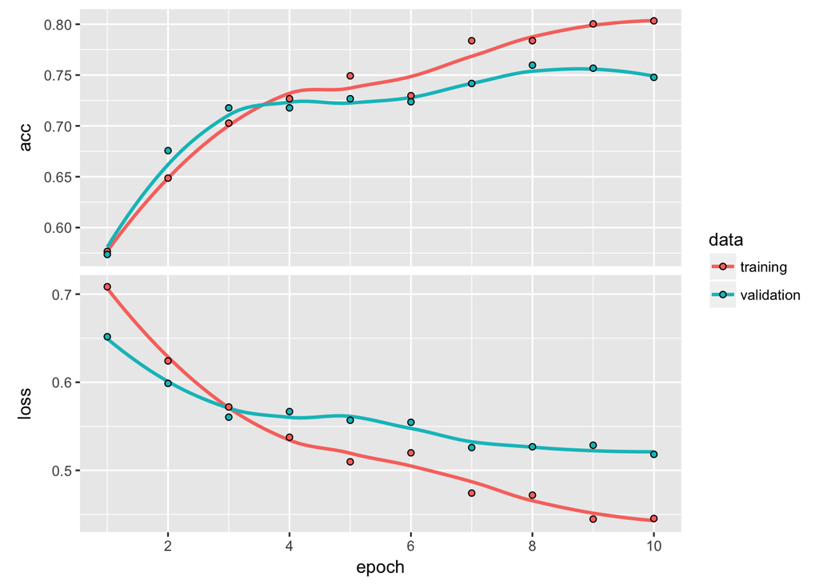

```r
model2 %>% compile(loss='categorical_crossentropy',
                   optimizer = optimizer_adagrad(lr=0.001),
                   metrics = c('accuracy'))

history <- model2 %>% fit(
  X_train, y_train,
  epochs = 10,
  validation_data=list(X_valid, y_valid)
)

plot(history)
```

```r
f17$predict_nn <- predict_classes(model2, x=X)
tapply(f17$predict_nn == y, f17$train_id, mean)
```

```
##      test     train     valid
##        NA 0.8228228 0.7477477
```

```r
table(y = f17$class[f17$train_id == "train"], x = f17$predict_nn[f17$train_id == "train"])
```

```
##    x
## y     0   1
##   0 297  52
##   1  66 251
```

```r
table(y = f17$class[f17$train_id == "valid"], x = f17$predict_nn[f17$train_id == "valid"])
```

```
##    x
## y     0   1
##   0 138  36
##   1  48 111
```

```r
model_blend <- glm(class ~ predict_nn + predict_min, data=f17,
                   subset = (train_id == "valid"))

summary(model_blend)
```

```
##
## Call:
## glm(formula = class ~ predict_nn + predict_min, data = f17, subset = (train_id ==
##     "valid"))
##
## Deviance Residuals:
##     Min       1Q   Median       3Q      Max
## -0.7926  -0.2163  -0.2163   0.2074   0.7837
##
## Coefficients:
##              Estimate Std. Error t value Pr(>|t|)
## (Intercept)   0.21626    0.03232   6.692 9.48e-11 ***
## predict_nn    0.25232    0.07084   3.562 0.000422 ***
## predict_min1  0.32399    0.07055   4.592 6.24e-06 ***
## ---
## Signif. codes:  0 '***' 0.001 '**' 0.01 '*' 0.05 '.' 0.1 ' ' 1
##
## (Dispersion parameter for gaussian family taken to be 0.1788616)
##
##     Null deviance: 83.081  on 332  degrees of freedom
## Residual deviance: 59.024  on 330  degrees of freedom
## AIC: 376.86
##
## Number of Fisher Scoring iterations: 2
```

```r
f17$outside_pred <- predict(model_blend, newdata=f17,type="response")
f17$outside_pred <- as.numeric(f17$outside_pred > 0.5)


tapply(f17$outside_pred == y, f17$train_id, mean)
```

```
##      test     train     valid
##        NA 0.8588589 0.7567568
```

# Submission

The code below assumes that you have added a prediction named `outside_pred` to every row of the dataset.

```r
submit <- select(f17, obs_id, outside_pred)
write_csv(submit, "class17_submit.csv")
```

Now, upload this file (ends with “.Rmd”), the HTML output (ends with “.nb.html” or “.html”), and the csv file to GitHub.